# Lista 1: Atrasos e Rotas na Internet

## iii. Provedores de serviço (ISP) envolvidos na rota fim a fim (sugere-se consulta em alguma base de dados de mapeamento de IP no ASN, número do sistema autônomo responsável pelo endereço IP, ex: https://asn.cymru.com)

Para esta questão, vamos realizar uma tabela onde relacionamos cada IP fornecido pelo comando `tracert www.caltech.edu` com a sua localização através obtidas pelo https://asn.cymru.com:

$\begin{array}{l|l|l} \textbf{AS} & \textbf{IP} & \textbf{AS Name} \\ \hline 27699 & 201.68.211.29 & TELEFONICA BRASIL S.A, BR \end{array}$

$-----------------------------$

$\begin{array}{l|l|l} \textbf{AS} & \textbf{IP} & \textbf{AS Name} \\ \hline 26599 & 152.255.150.162 & TELEFONICA\; BRASIL\; S.A,\; BR \end{array}$

$-----------------------------$

$\begin{array}{l|l|l} \textbf{AS} & \textbf{IP} & \textbf{AS Name} \\ \hline 12956 & 84.16.7.102 & TELEFONICA\; TELXIUS,\; ES \end{array}$

$-----------------------------$

$\begin{array}{l|l|l} \textbf{AS} & \textbf{IP} & \textbf{AS Name} \\ \hline 12956 & 213.140.36.62 & TELEFONICA\; TELXIUS,\; ES \end{array}$

$-----------------------------$

$\begin{array}{l|l|l} \textbf{AS} & \textbf{IP} & \textbf{AS Name} \\ \hline 12956 & 5.53.0.157 & TELEFONICA\; TELXIUS,\; ES \end{array}$

$-----------------------------$

$\begin{array}{l|l|l} \textbf{AS} & \textbf{IP} & \textbf{AS Name} \\ \hline 13335 & 172.68.16.33 & CLOUDFLARENET,\; US \end{array}$

$-----------------------------$

$\begin{array}{l|l|l} \textbf{AS} & \textbf{IP} & \textbf{AS Name} \\ \hline 13335 & 104.18.15.60 & CLOUDFLARENET,\; US \end{array}$

Neste caso, devido ao acesso à base de dados diferentes, podemos observar uma divergência do local para os IPs `84.16.7.102`, `213.140.36.62` e `5.53.0.157`. Para os outros IPs temos as mesmas localizações e organização.

## iv. Desenhe uma figura ilustrando a rota dos pacotes e os diferentes saltos no nível de roteadores, sistemas autonomos, e países/cidades dos elementos de rede envolvidos.

Para este caso, usaremos o retorno do mapeamento dado por https://stefansundin.github.io/traceroute-mapper/.

[figure not shown]

Aqui, vemos que este visualizador de `traceroute` utiliza dos dados geográficos fornecidos em www.iplocation.net.

# Discussão e Conclusão

Em nossa análise, nota-se uma discordância entre a distância SP/Brasil → CA/Estados Unidos, pois torna-se inverossímel termos praticamente $10.000km$ percorridos em apenas $10ms$ aproximadamente. Com isso em mente, fomos pesquisar e nos informar melhor da situação que nos encontramos com o endereço www.caltech.edu.

No seguinte link https://www.imperva.com/learn/performance/round-trip-time-rtt/ encontramos informações sobre como reduzir o *RTT* (*Round Trip Time*, em português: Tempo de Ida e Volta) de uma conexão: através de *CDN* (*Content Delivery Networks*, em português: Redes de Entrega de Conteúdo) onde, através deste link https://www.imperva.com/learn/performance/what-is-cdn-how-it-works/, nos diz que a missão do CDN é encurtar virtualmente a distância física entre origem e destino, com o objetivo de melhorar a velocidade e o desempenho da renderização de um site.

O modo de funcionamento do CDN é através de memórias em cache: focando na minimização da distância entre os visitantes e o servidor de um site, CDN armazena uma versão em cache do conteúdo do site em várias localizações geográficas (também conhecidas como Pontos de Presença ou *PoPs*, em inglês *Points of Presence*). Cada PoP contém vários servidores de cache responsáveis pela entrega de conteúdo aos visitantes em sua proximidade.

A partir disso, é possível entendermos a razão do tempo pequeno de $10ms$ para que fosse "percorrido" $10.000km$, o endereço www.caltech.edu estava na memória cache e, assim o conteúdo do endereço foi entregue rapidamente.

Observando ainda mais os resutlados das pesquisas dos IPs que obtivemos no `tracert`, temos a Cloudflare como organização responsável do link www.caltech.edu. Ao entrar no site da Cloudflare https://www.cloudflare.com/pt-br/network/, vemos que temos PoPs em Campinas e em São Paulo capital, explicando, mais uma vez, a razão de uma conexão tão rápida com e universidade Caltech.

A imagem abaixo demonstra um exemplo de redução de tempo ao usar CDN.

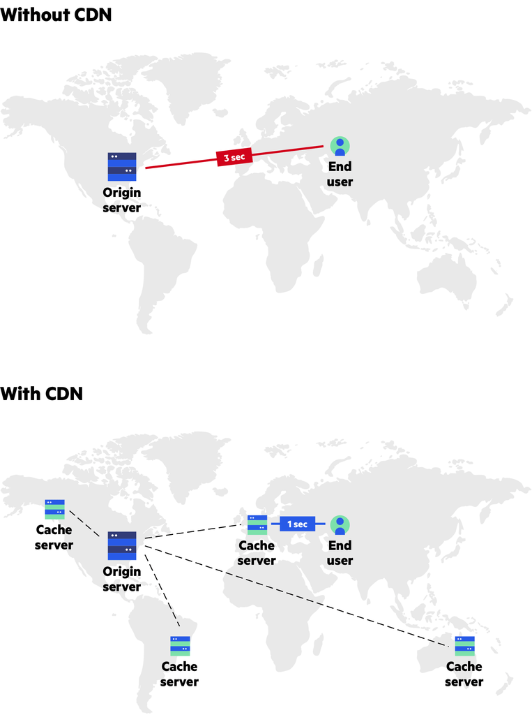